# Learning the manner we perform barbell lifts from wearable devices’ data

A. C. L.

July 2015

### Introduction

We want to predict the manner in which we perform barbell lifts, based on the data recorded from wearable devices such s Jawbone Up, FuelBand and Fitbit etc. (See [1]). In the data set ([1]), the “classe” variable classifies the data into five classes, namely A, B, C, D and E. The label A indicates the associated exercise is being performed correctly and the other four represent four different types of mistakes. Our work is to develop a classifier via machine learning algorithms given in the `caret` R-package. As the quality of the classifier will be assessed by the accuracy of predictions on 20 test cases, we will use *random forests* as the method to construct the classifier (See [3]).

Our work is developed by stages and will be listed in the coming sections.

### Stage A: Exploratory Data Analysis

```r
dat<-read.csv("pml-training.csv")
test<-read.csv("pml-testing.csv")
dim(dat)
```

```
## [1] 19622   160
```

```r
dim(test)
```

```
## [1]  20 160
```

Note that the number of features (columns) is 160. We will like to reduce it by eliminating some of them that are not relevant to our studies. By consulting the documentation and visual inspection, we may eliminate the first seven columns of the data set (i.e. “X” , “user_name”, “raw_timestamp_part_1”, [4] “raw_timestamp_part_2”, “cvtd_timestamp”, “new_window”, “num_window”). In addition to eliminating the first seven columns, we like to remove columns with incomplete information. That is, we plan to eliminate columns with entries that are either “NA” or “” (blank)

### Stage B: Pre-process the data

We will carry out the elimination stated earlier as follows (see [2]):

```r
dat<-read.csv("pml-training.csv", na.strings=c("NA",""))
dat<-dat[,-c(1:7)]                      ## eliminate the first 7 columns
dat <- dat[, colSums(is.na(dat)) == 0]  ## elininate columns with "NA" or "" entries
dim(dat)                                ## the columns represents the features extracted
```

```
## [1] 19622    53
```

The data is now named as `dat`. It has 53 features (including classe) and the number of rows (19622) remains unchanged.

### Stage C: Construct the classifier

We use basic functions from the `caret` package to the data for training, testing and cross validation. Our work rely on the `train` function from the `caret` package to construct the classifier. Our work are:

- **Split Data**

we sub-divide the pre-processed data `dat` into 3 parts: 60% for training , 20% for validating and 20% for testing. They are called `datTrain`, `datValid` and `datTest` respectively.

```r
require(caret)
set.seed(72015)
## Prepare Training Data
inTrain<-createDataPartition(y=dat$classe, p=0.6,list=FALSE)
datTrain<-dat[inTrain,]
## Prepare Validating and Testing Data
datNotTrain<-dat[-inTrain,]
inValid<-createDataPartition(y=datNotTrain$classe,p=0.5,list=FALSE)
datValid<-datNotTrain[inValid,]
datTest<-datNotTrain[-inValid,]
## Examine the size of the splitted data sets
dim(datTrain)
```

```
## [1] 11776    53
```

```r
dim(datValid)
```

```
## [1] 3923   53
```

```r
dim(datTest)
```

```
## [1] 3923   53
```

- **Training the Classifier**

We use the `train` function from the `caret` package to train the classifier. In particular, we use the random forest method (option `method="rf"`). It tends to have better accuracy (See comments in [3])

Note that *cross validation* are performed within the `train` function by setting the option in `trControl`. In our case, we use *5*-fold cross validation in the training process. The training calls and the resulting are displayed below:

```r
datTrControl<-trainControl(method="cv", number = 5) ## set train control option for using
                                                    ## 5-fold cross validation
model<-train(classe ~., method="rf", data=datTrain, trControl=datTrControl,
             ntree = 50, importance = TRUE)         ## apply random forest to get a classifier
model                                               ## display model optained
```

```
## Random Forest
##
## 11776 samples
##    52 predictors
##     5 classes: 'A', 'B', 'C', 'D', 'E'
##
## No pre-processing
## Resampling: Cross-Validated (5 fold)
##
## Summary of sample sizes: 9421, 9421, 9422, 9420, 9420
##
## Resampling results across tuning parameters:
##
##   mtry  Accuracy   Kappa      Accuracy SD  Kappa SD
##    2    0.9857339  0.9819499  0.003084371  0.003902107
##   27    0.9869227  0.9834567  0.002518070  0.003185017
##   52    0.9817424  0.9769029  0.004084493  0.005163700
##
## Accuracy was used to select the optimal model using  the largest value.
## The final value used for the model was mtry = 27.
```

- **Valdation**

To continue our cross validation work, we will now apply the classifier `model` to the Validation data and examine the confusion matrix:

```r
modelValidate<-predict(model,datValid)              ## apply the classifier for validation
CMV<-confusionMatrix(datValid$classe,modelValidate)  ## examine the confusion matrix
CMV$table
```

```
##           Reference
## Prediction    A    B    C    D    E
##          A 1114    1    0    0    1
##          B    8  750    1    0    0
##          C    0    4  674    6    0
##          D    0    0   10  632    1
##          E    0    0    0    4  717
```

- **Estimate Out of Sample Error** The confusion matrix shown indicates that reasonable accuracy is acheived when apply the classifier to the validation data. In addition, the accuracy rate and the estimated out of sample error are:

```r
accuracyRateV <- postResample(datValid$classe,modelValidate)
accuracyRateV
```

```
##  Accuracy     Kappa
## 0.9908233 0.9883906
```

```r
outOfSampleError <- 1-accuracyRateV
outOfSampleError
```

```
##    Accuracy       Kappa
## 0.009176651 0.011609384
```

Both accuracy rate and out of sample error reported seems satisfactory and we continue our work on testing data.

- **Testing**

We apply the classifier `model` to the Test data and obtain `modelTest`. Again we examine the confusion matrix:

```r
modelTest<-predict(model,datTest)               ## apply the classifier for testing
CMT<-confusionMatrix(datTest$classe,modelTest)  ## examine the confusion matrix
CMT$table
```

```
##           Reference
## Prediction    A    B    C    D    E
##          A 1114    2    0    0    0
##          B    6  751    2    0    0
##          C    0    3  678    3    0
##          D    0    0   15  627    1
##          E    0    1    2    3  715
```

- **Estimate Out of Sample Error** The confusion matrix shown indicates that satisfactory accuracy is acheived when apply the classifier to the testing data. The accuracy rate and the estimated out of sample error in testing are:

```r
accuracyRateT <- postResample(datValid$classe,modelTest)
accuracyRateT
```

[output not shown]

```r
outOfSampleError <- 1-accuracyRateT
outOfSampleError
```

[output not shown]

Both accuracy rate and out of sample error reported also seems satisfactory. Hence, we consider the classifier obtained our final classifier and will use it for the twenty test data given in `test`. Note that the high Kappa values obtained in both validation and testing phase also seems to suggest that the classifier obtained should give satisfactory performance for the test data.

### Prepare testing results for submission

- **Generate twenty testing results for submission**

We prepare the twenty test data via similar pre-precessing procedures:

```r
twentytest<-read.csv("pml-testing.csv", na.strings=c("NA",""))
twentytest<-twentytest[,-c(1:7)]
twentytest <- twentytest[, colSums(is.na(twentytest)) == 0]
dim(twentytest)
```

```
## [1] 20 53
```

and compute the answers as follows:

```r
answers<- predict(model, twentytest)
as.character(answers)
```

```
##  [1] "B" "A" "B" "A" "A" "E" "D" "B" "A" "A" "B" "C" "B" "A" "E" "E" "A"
## [18] "B" "B" "B"
```

### Final remarks

The classifier pass all the twenty test results, according to the evaluation results given online and suggests that the classifier obtained is satisfactory in terms of accuracy.

It should be noted that the running time for training the classifier is long. As future work, we may need to reduce the number of predictors (features). The caret package and others (ex. mlbench)(see [4]) do provide tools for feature selection. For example:

```r
library(randomForest)
importance <- varImp(model, scale=FALSE)
```

rank the `rf` variables and the *20* most important variables are listed below:

```r
print(importance)
```

```
## rf variable importance
##
##   variables are sorted by maximum importance across the classes
##   only 20 most important variables shown (out of 52)
##
##                           A      B      C      D      E
## pitch_belt            8.330 29.004 18.344 11.596 11.906
## roll_belt            18.965 25.498 22.966 21.617 26.370
## pitch_forearm        17.916 21.429 23.432 17.089 16.268
## magnet_dumbbell_z    17.863 15.303 21.526 14.921 15.213
## magnet_dumbbell_y    21.349 18.216 18.783 17.688 15.012
## yaw_belt             15.775 19.232 16.237 16.441 12.112
## yaw_arm              13.329  7.126 10.098  9.421  6.540
## roll_forearm         11.786 10.336 11.275  9.354  9.366
## magnet_belt_y         6.555 11.203  8.245  8.759  9.815
## gyros_dumbbell_y     11.067  8.556 11.174  6.529  5.670
## accel_dumbbell_y     11.139  7.258 11.049  9.072 10.127
## accel_dumbbell_z      9.594  9.328  6.773  8.263 11.099
## accel_forearm_x       6.748 10.395  9.780 11.014 10.208
## gyros_belt_x         10.505  5.125  5.464  4.735  5.299
## magnet_belt_z         6.403  9.873  5.929  9.104  6.803
## magnet_belt_x         4.582  9.670  9.282  4.595  7.811
## accel_belt_z          5.667  6.160  9.413  6.170  6.235
## magnet_arm_y          6.178  9.317  7.688  8.170  6.364
## total_accel_dumbbell  5.542  9.255  7.985  8.021  8.807
## gyros_belt_z          9.252  8.712  8.156  5.887  8.564
```

We can also examine the following plot:

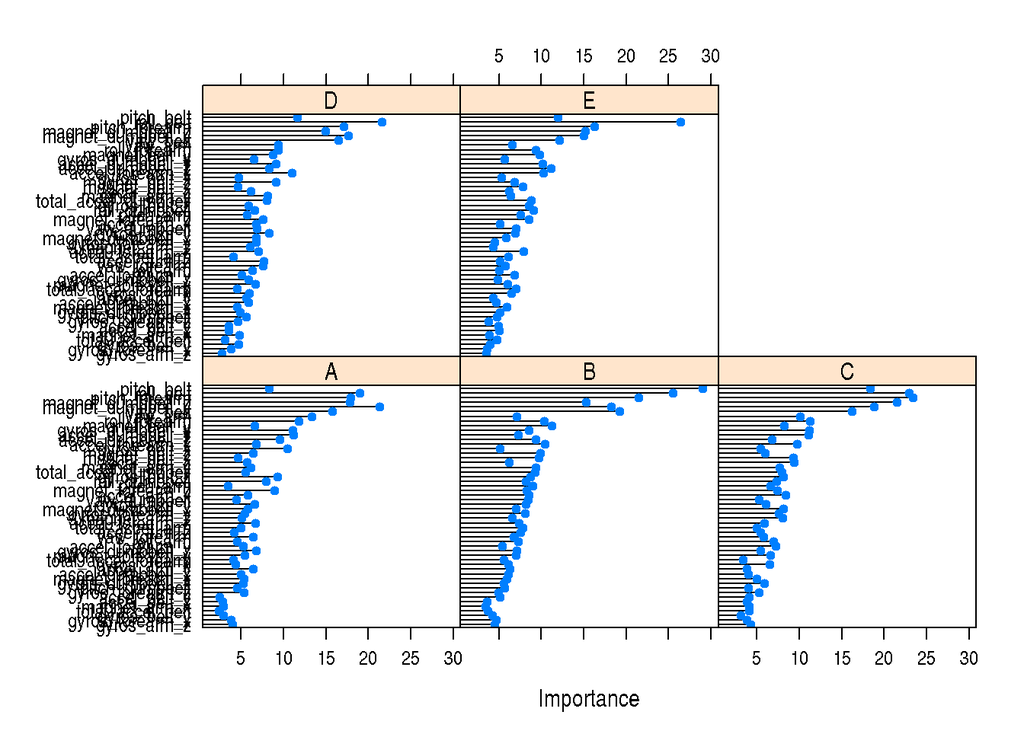

```r
plot(importance)
```

It seems that additional exploratory work on selection of features is necessary to speed up the model building process. I guess input from domain experts (on barbell lift) in selecting a smaller number but significant features may help.

### Acknowledgement

1. Velloso, E.; Bulling, A.; Gellersen, H.; Ugulino, W.; Fuks, H. Qualitative Activity Recognition of Weight Lifting Exercises. Proceedings of 4th International Conference in Cooperation with SIGCHI (Augmented Human ’13) . Stuttgart, Germany: ACM SIGCHI, 2013. ( The data for this project come from this source: http://groupware.les.inf.puc-rio.br/har )
2. http://stackoverflow.com/questions/12763890/exclude-blank-and-na-in-r
3. J Leek, Random Forests (slides used in lectures)
4. Jason Brownlee, http://machinelearningmastery.com/feature-selection-with-the-caret-r-package/, September 22, 2014